# Choosing reasonable amounts of heterogeneity for our theoretical examples and the Shiny app

For the theoretical analyses and the Shiny App, we had to select reasonable values for the (residual) between study variances $\tau^2$. To reflect $\tau^2$-estimates in Psychology, we based our choice of $\tau^2$ on a dataset by van [Erp et al. (2017)](https://openpsychologydata.metajnl.com/articles/jopd.33) which can be accessed via this [link](https://doi.org/10.5334/jopd.33.s2). The dataset contains 705 heterogeneity estimates from 61 meta-analyses published in Psychological Bulletin between 1990 and 2013. As all examples in our paper use standardized mean differences as effect size, we filtered the this dataset for $\tau^2$-estimates that came from a meta-analysis in the effect size was a standardized mean difference.

The following code details how we obtained the first, second and third quantile of the observed tau2 estimates.

```r
# Import the data
url <- "https://doi.org/10.5334/jopd.33.s2"
file_name <- "vanErp.xlsx"
file_path <-  getwd()
destfile <- paste0(file_path,"/", file_name, sep = "")
download.file(url = url, destfile = destfile, mode = "wb")
data <- readxl::read_excel(destfile)
```

```r
# we are interested only in tau2 estimates where SMD were the effect sizes, however,
# the dataset also contains information from meta-analyses with different effect sizes
unique(data$`Type of ES`)
```

```
##  [1] "Cohen's d"                      "Hedges' g"
##  [3] "Pearson's r"                    "Corrected Pearson's r"
##  [5] "Standardized mean gains"        "Corrected Cohen's d"
##  [7] "Weighted mean"                  "mean WLS ES"
##  [9] "Weighted Pearson's r"           "Weighted Cohen's d"
## [11] "Unweighted mean"                "Unweighted Pearson's r"
## [13] "Weighted corrected Pearson's r"
```

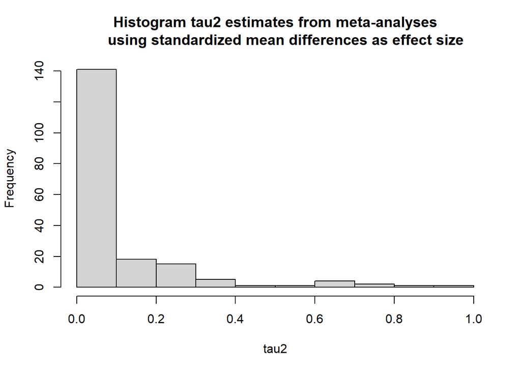

```r
# select SMD effect sizes only
data.SMD <- subset(data, `Type of ES` %in%
                  c("Cohen's d" , "Hedges' g", "Corrected Cohen's d" ,"Weighted Cohen's d"))

# show the histogram of tau2 estimates
hist(data.SMD$`tau^2`, xlab = "tau2", main = "Histogram tau2 estimates from meta-analyses
     using standardized mean differences as effect size")
```

```r
# obtain the quantiles
Q1 <- quantile(data.SMD$`tau^2`,  0.25, na.rm = TRUE)
Q2 <- quantile(data.SMD$`tau^2`,  0.5, na.rm = TRUE)
Q3 <- quantile(data.SMD$`tau^2`,  0.75, na.rm = TRUE)
```

Of the 705 $\tau^2$-estimates in the data, only 189 belong to meta-analyses using standardized mean differences. The frequency of $\tau^2$-estimates is shown in the histogram. The $\tau^2$ distribution yields the following quantiles:

- Q1 = 0.01
- Q2 = 0.04
- Q3 = 0.11.

As a side note, all calculations in the paper and in the app can also be done by specifying certain (residual) $I^2$ values instead of specifying $\tau^2$.